# Class 2: Manipulating Data

Luke Sonnet

Base R cheatsheet: https://www.rstudio.com/wp-content/uploads/2016/05/base-r.pdf

tidyverse cheatsheet: https://www.rstudio.com/wp-content/uploads/2015/02/data-wrangling-cheatsheet.pdf

## Basic data manipulation

Most of the work you do in R actually has to do with tweaking, summarizing, modifying, and otherwise manipulating data. Let’s go ahead and use a simplified panel of country level data over time and work from there.

```r
library(tidyverse)
qog <- read_csv("https://raw.githubusercontent.com/lukesonnet/r_introduction/master/data/qog/qog_ts.csv")
glimpse(qog)
```

```
## Observations: 7,770
## Variables: 13
## $ ccode                <int> 4, 4, 4, 4, 4, 4, 4, 4, 4, 4, 4, 4, 4, 4,...
## $ cname                <chr> "Afghanistan", "Afghanistan", "Afghanista...
## $ year                 <int> 1981, 1982, 1983, 1984, 1985, 1986, 1987,...
## $ ccodewb              <int> 4, 4, 4, 4, 4, 4, 4, 4, 4, 4, 4, 4, 4, 4,...
## $ gle_pop              <dbl> 15862, 15549, 15177, 14814, 14519, 14300,...
## $ wdi_expedu           <dbl> 1.90443, 1.73199, NA, NA, NA, NA, NA, NA,...
## $ wdi_exphpu           <dbl> NA, NA, NA, NA, NA, NA, NA, NA, NA, NA, N...
## $ wdi_expmil           <dbl> NA, NA, NA, NA, NA, NA, NA, NA, NA, NA, N...
## $ wdi_lifexp           <dbl> 42.53361, 43.23590, 43.98010, 44.76220, 4...
## $ wdi_gdpcapcon2010    <dbl> NA, NA, NA, NA, NA, NA, NA, NA, NA, NA, N...
## $ wdi_gdpcappppcon2011 <dbl> NA, NA, NA, NA, NA, NA, NA, NA, NA, NA, N...
## $ fh_feb               <int> NA, NA, NA, NA, NA, NA, NA, NA, NA, NA, N...
## $ fh_ipolity2          <dbl> 0.3988471, NA, 0.3988471, 0.3988471, 0.39...
```

```r
table(qog$cname)
```

```
##
##                   Afghanistan                       Albania
##                            37                            37
##                       Algeria                       Andorra
##                            37                            37
##                        Angola           Antigua and Barbuda
##                            37                            37
##                     Argentina                       Armenia
##                            37                            37
##                     Australia                       Austria
##                            37                            37
##                    Azerbaijan                       Bahamas
##                            37                            37
##                       Bahrain                    Bangladesh
##                            37                            37
##                      Barbados                       Belarus
##                            37                            37
##                       Belgium                        Belize
##                            37                            37
##                         Benin                        Bhutan
##                            37                            37
##                       Bolivia        Bosnia and Herzegovina
##                            37                            37
##                      Botswana                        Brazil
##                            37                            37
##                        Brunei                      Bulgaria
##                            37                            37
##                  Burkina Faso                       Burundi
##                            37                            37
##                      Cambodia                      Cameroon
##                            37                            37
##                        Canada                    Cape Verde
##                            37                            37
##      Central African Republic                          Chad
##                            37                            37
##                         Chile                         China
##                            37                            37
##                      Colombia                       Comoros
##                            37                            37
##                         Congo    Congo, Democratic Republic
```

[output cut: 156 more lines]

```
##                            37                            37
##                       Uruguay                          USSR
##                            37                            37
##                    Uzbekistan                       Vanuatu
##                            37                            37
##                     Venezuela                       Vietnam
##                            37                            37
##                Vietnam, North                Vietnam, South
##                            37                            37
##                         Yemen                  Yemen, North
##                            37                            37
##                  Yemen, South                    Yugoslavia
##                            37                            37
##                        Zambia                      Zimbabwe
##                            37                            37
```

```r
table(qog$year)
```

```
##
## 1981 1982 1983 1984 1985 1986 1987 1988 1989 1990 1991 1992 1993 1994 1995
##  210  210  210  210  210  210  210  210  210  210  210  210  210  210  210
## 1996 1997 1998 1999 2000 2001 2002 2003 2004 2005 2006 2007 2008 2009 2010
##  210  210  210  210  210  210  210  210  210  210  210  210  210  210  210
## 2011 2012 2013 2014 2015 2016 2017
##  210  210  210  210  210  210  210
```

```r
table(qog$cname, qog$year)
```

```
##
##                                 1981 1982 1983 1984 1985 1986 1987 1988
##   Afghanistan                      1    1    1    1    1    1    1    1
##   Albania                          1    1    1    1    1    1    1    1
##   Algeria                          1    1    1    1    1    1    1    1
##   Andorra                          1    1    1    1    1    1    1    1
##   Angola                           1    1    1    1    1    1    1    1
##   Antigua and Barbuda              1    1    1    1    1    1    1    1
##   Argentina                        1    1    1    1    1    1    1    1
##   Armenia                          1    1    1    1    1    1    1    1
##   Australia                        1    1    1    1    1    1    1    1
##   Austria                          1    1    1    1    1    1    1    1
##   Azerbaijan                       1    1    1    1    1    1    1    1
##   Bahamas                          1    1    1    1    1    1    1    1
##   Bahrain                          1    1    1    1    1    1    1    1
##   Bangladesh                       1    1    1    1    1    1    1    1
##   Barbados                         1    1    1    1    1    1    1    1
##   Belarus                          1    1    1    1    1    1    1    1
##   Belgium                          1    1    1    1    1    1    1    1
##   Belize                           1    1    1    1    1    1    1    1
##   Benin                            1    1    1    1    1    1    1    1
##   Bhutan                           1    1    1    1    1    1    1    1
##   Bolivia                          1    1    1    1    1    1    1    1
##   Bosnia and Herzegovina           1    1    1    1    1    1    1    1
##   Botswana                         1    1    1    1    1    1    1    1
##   Brazil                           1    1    1    1    1    1    1    1
##   Brunei                           1    1    1    1    1    1    1    1
##   Bulgaria                         1    1    1    1    1    1    1    1
##   Burkina Faso                     1    1    1    1    1    1    1    1
##   Burundi                          1    1    1    1    1    1    1    1
##   Cambodia                         1    1    1    1    1    1    1    1
##   Cameroon                         1    1    1    1    1    1    1    1
##   Canada                           1    1    1    1    1    1    1    1
##   Cape Verde                       1    1    1    1    1    1    1    1
##   Central African Republic         1    1    1    1    1    1    1    1
##   Chad                             1    1    1    1    1    1    1    1
##   Chile                            1    1    1    1    1    1    1    1
##   China                            1    1    1    1    1    1    1    1
##   Colombia                         1    1    1    1    1    1    1    1
##   Comoros                          1    1    1    1    1    1    1    1
```

[output cut: 1005 more lines]

```
##   United States                    1    1    1    1    1
##   Uruguay                          1    1    1    1    1
##   USSR                             1    1    1    1    1
##   Uzbekistan                       1    1    1    1    1
##   Vanuatu                          1    1    1    1    1
##   Venezuela                        1    1    1    1    1
##   Vietnam                          1    1    1    1    1
##   Vietnam, North                   1    1    1    1    1
##   Vietnam, South                   1    1    1    1    1
##   Yemen                            1    1    1    1    1
##   Yemen, North                     1    1    1    1    1
##   Yemen, South                     1    1    1    1    1
##   Yugoslavia                       1    1    1    1    1
##   Zambia                           1    1    1    1    1
##   Zimbabwe                         1    1    1    1    1
```

First let’s figure out how to create new variables. As we discussed yesterday, it can be as simple as just storing a vector in a data.frame.

```r
qog$test <- 1
glimpse(qog)
```

```
## Observations: 7,770
## Variables: 14
## $ ccode                <int> 4, 4, 4, 4, 4, 4, 4, 4, 4, 4, 4, 4, 4, 4,...
## $ cname                <chr> "Afghanistan", "Afghanistan", "Afghanista...
## $ year                 <int> 1981, 1982, 1983, 1984, 1985, 1986, 1987,...
## $ ccodewb              <int> 4, 4, 4, 4, 4, 4, 4, 4, 4, 4, 4, 4, 4, 4,...
## $ gle_pop              <dbl> 15862, 15549, 15177, 14814, 14519, 14300,...
## $ wdi_expedu           <dbl> 1.90443, 1.73199, NA, NA, NA, NA, NA, NA,...
## $ wdi_exphpu           <dbl> NA, NA, NA, NA, NA, NA, NA, NA, NA, NA, N...
## $ wdi_expmil           <dbl> NA, NA, NA, NA, NA, NA, NA, NA, NA, NA, N...
## $ wdi_lifexp           <dbl> 42.53361, 43.23590, 43.98010, 44.76220, 4...
## $ wdi_gdpcapcon2010    <dbl> NA, NA, NA, NA, NA, NA, NA, NA, NA, NA, N...
## $ wdi_gdpcappppcon2011 <dbl> NA, NA, NA, NA, NA, NA, NA, NA, NA, NA, N...
## $ fh_feb               <int> NA, NA, NA, NA, NA, NA, NA, NA, NA, NA, N...
## $ fh_ipolity2          <dbl> 0.3988471, NA, 0.3988471, 0.3988471, 0.39...
## $ test                 <dbl> 1, 1, 1, 1, 1, 1, 1, 1, 1, 1, 1, 1, 1, 1,...
```

```r
table(qog$test)
```

```
##
##    1
## 7770
```

What happens when we just pass a number instead of a vector? Remember, what is recycling?

```r
qog$test2 <- 1:7
```

```r
qog$copy_code <- qog$ccode
table(qog$copy_code, qog$ccode)
```

```
##
##        4  8 12 20 24 28 31 32 36 40 44 48 50 51 52 56 64 68 70 72 76 84 90
##   4   37  0  0  0  0  0  0  0  0  0  0  0  0  0  0  0  0  0  0  0  0  0  0
##   8    0 37  0  0  0  0  0  0  0  0  0  0  0  0  0  0  0  0  0  0  0  0  0
##   12   0  0 37  0  0  0  0  0  0  0  0  0  0  0  0  0  0  0  0  0  0  0  0
##   20   0  0  0 37  0  0  0  0  0  0  0  0  0  0  0  0  0  0  0  0  0  0  0
##   24   0  0  0  0 37  0  0  0  0  0  0  0  0  0  0  0  0  0  0  0  0  0  0
##   28   0  0  0  0  0 37  0  0  0  0  0  0  0  0  0  0  0  0  0  0  0  0  0
##   31   0  0  0  0  0  0 37  0  0  0  0  0  0  0  0  0  0  0  0  0  0  0  0
##   32   0  0  0  0  0  0  0 37  0  0  0  0  0  0  0  0  0  0  0  0  0  0  0
##   36   0  0  0  0  0  0  0  0 37  0  0  0  0  0  0  0  0  0  0  0  0  0  0
##   40   0  0  0  0  0  0  0  0  0 37  0  0  0  0  0  0  0  0  0  0  0  0  0
##   44   0  0  0  0  0  0  0  0  0  0 37  0  0  0  0  0  0  0  0  0  0  0  0
##   48   0  0  0  0  0  0  0  0  0  0  0 37  0  0  0  0  0  0  0  0  0  0  0
##   50   0  0  0  0  0  0  0  0  0  0  0  0 37  0  0  0  0  0  0  0  0  0  0
```

[output cut: 2529 more lines]

```r
table(qog$copy_code, qog$ccode)[1:5, 1:5]
```

```
##
##       4  8 12 20 24
##   4  37  0  0  0  0
##   8   0 37  0  0  0
##   12  0  0 37  0  0
##   20  0  0  0 37  0
##   24  0  0  0  0 37
```

```r
with(qog, table(copy_code, ccode))
```

```
##          ccode
## copy_code  4  8 12 20 24 28 31 32 36 40 44 48 50 51 52 56 64 68 70 72 76
##       4   37  0  0  0  0  0  0  0  0  0  0  0  0  0  0  0  0  0  0  0  0
##       8    0 37  0  0  0  0  0  0  0  0  0  0  0  0  0  0  0  0  0  0  0
##       12   0  0 37  0  0  0  0  0  0  0  0  0  0  0  0  0  0  0  0  0  0
##       20   0  0  0 37  0  0  0  0  0  0  0  0  0  0  0  0  0  0  0  0  0
##       24   0  0  0  0 37  0  0  0  0  0  0  0  0  0  0  0  0  0  0  0  0
##       28   0  0  0  0  0 37  0  0  0  0  0  0  0  0  0  0  0  0  0  0  0
##       31   0  0  0  0  0  0 37  0  0  0  0  0  0  0  0  0  0  0  0  0  0
##       32   0  0  0  0  0  0  0 37  0  0  0  0  0  0  0  0  0  0  0  0  0
##       36   0  0  0  0  0  0  0  0 37  0  0  0  0  0  0  0  0  0  0  0  0
##       40   0  0  0  0  0  0  0  0  0 37  0  0  0  0  0  0  0  0  0  0  0
##       44   0  0  0  0  0  0  0  0  0  0 37  0  0  0  0  0  0  0  0  0  0
##       48   0  0  0  0  0  0  0  0  0  0  0 37  0  0  0  0  0  0  0  0  0
##       50   0  0  0  0  0  0  0  0  0  0  0  0 37  0  0  0  0  0  0  0  0
```

[output cut: 2741 more lines]

```r
with(qog, table(copy_code, ccode))[1:5, 1:5]
```

```
##          ccode
## copy_code  4  8 12 20 24
##        4  37  0  0  0  0
##        8   0 37  0  0  0
##        12  0  0 37  0  0
##        20  0  0  0 37  0
##        24  0  0  0  0 37
```

We can also use the `ifelse()` function which is really useful.

```r
# basic usage
x <- c(-1, -0.5, 1)
x < 0
```

```
## [1]  TRUE  TRUE FALSE
```

```r
ifelse(x < 0, "negative", "positive")
```

```
## [1] "negative" "negative" "positive"
```

```r
# example data usage
qog$pakistan <- ifelse(qog$cname == "Pakistan", 1, 0)
table(qog$pakistan)
```

```
##
##    0    1
## 7733   37
```

```r
qog$pakistan <- qog$cname == "Pakistan"
table(qog$pakistan)
```

```
##
## FALSE  TRUE
##  7733    37
```

```r
qog$pakistan <- as.numeric(qog$cname == "Pakistan")
table(qog$pakistan)
```

```
##
##    0    1
## 7733   37
```

```r
qog$is_this_pakistan <- ifelse(qog$cname == "Pakistan", "yes", "no")
table(qog$pakistan, qog$is_this_pakistan)
```

```
##
##       no  yes
##   0 7733    0
##   1    0   37
```

We can see the population in `gle_pop`. What scale is it on? We can use a histogram to help us out here. Use the `hist()` function.

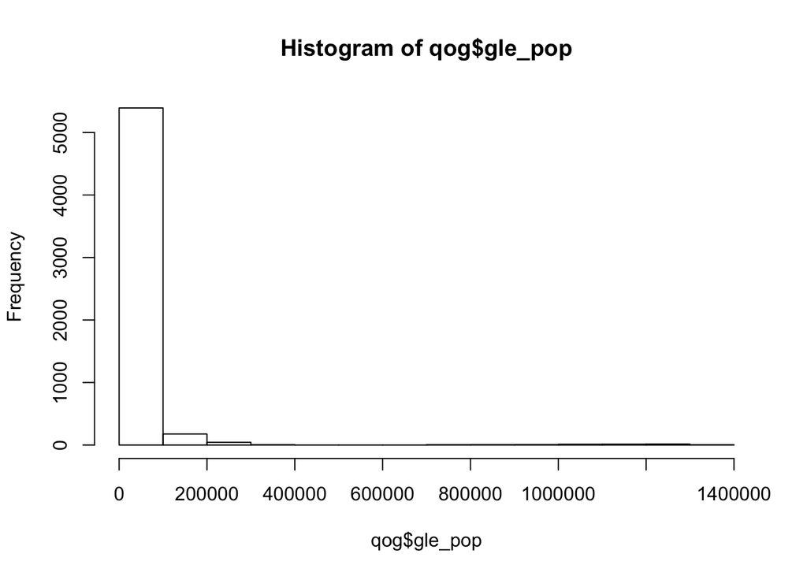

```r
hist(qog$gle_pop)
```

Look’s like it’s probably in thousands. Lets change it to raw numbers.

```r
qog$gle_pop_raw <- qog$gle_pop * 1000
```

We can use `plot()` to do a simple scatter plot and see what happened.

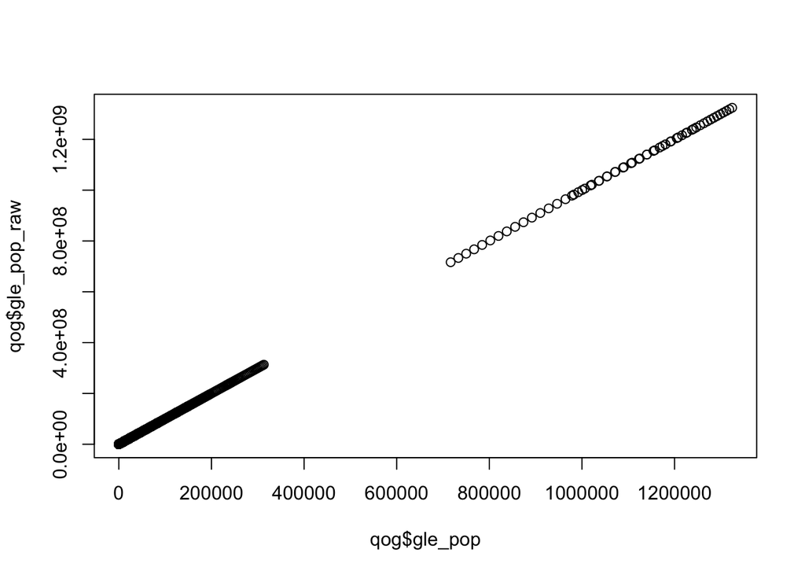

```r
plot(qog$gle_pop, qog$gle_pop_raw)
```

Let’s make another histogram of life expectancy.

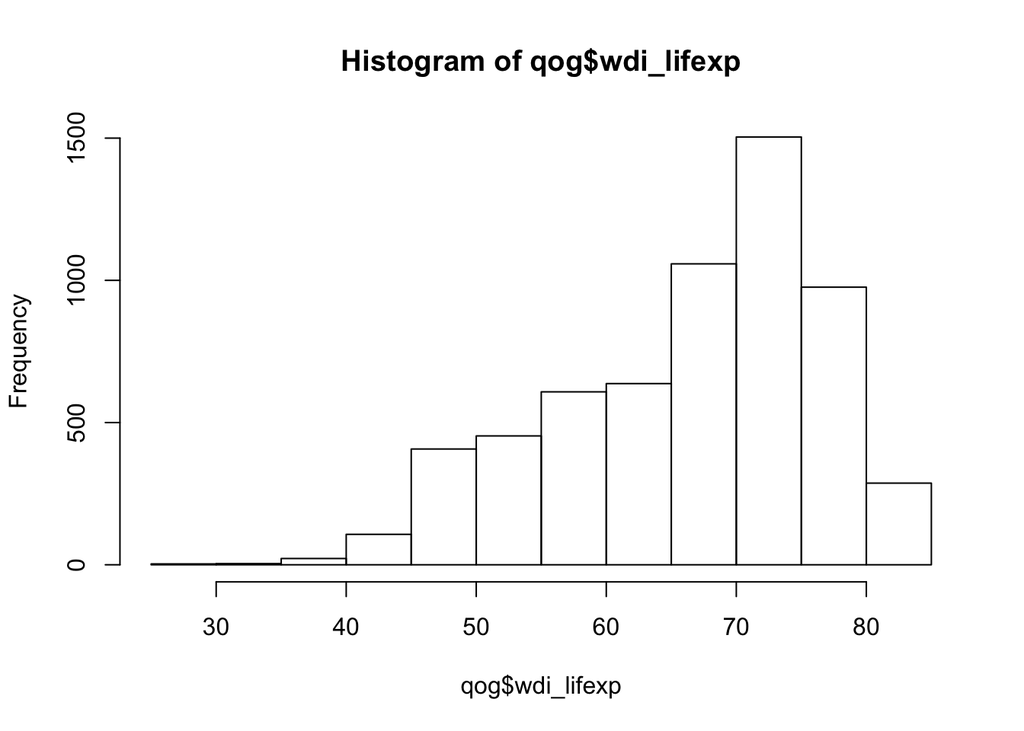

```r
hist(qog$wdi_lifexp)
```

```r
max(qog$wdi_lifexp)
```

```
## [1] NA
```

```r
max(qog$wdi_lifexp, na.rm = TRUE)
```

```
## [1] 83.84366
```

What years are we missing data for life expectancy? There are some packages for this, but we can also do it manually.

```r
table(qog$year, is.na(qog$wdi_lifexp))
```

```
##
##        FALSE TRUE
##   1981   150   60
##   1982   154   56
##   1983   152   58
##   1984   153   57
##   1985   153   57
##   1986   153   57
##   1987   158   52
##   1988   154   56
##   1989   154   56
##   1990   156   54
##   1991   157   53
##   1992   177   33
##   1993   178   32
```

[output cut: 24 more lines]

**Exercise:** Using the filtering commands we used yesterday, pick out all of the rows that correspond to year 2011. Save this as a new dataset called `qog_2011`. Hint: you’ll need to use the `[]` braces and you’ll need to use a logical statement to select rows, while keeping all of the columns.

Then pass the `wdi_lifexp` column the `hist()` function to get a histogram of the life expectancy in 2011. Then look at a scatter plot comparing `wdi_lifexp` and `wdi_gdpcappppcon2011`, the GDP per capita. Use the `plot()` function. If you’re done and have time, check the other commands in the `?plot` function. See if you can change the axis labels.

**Exercise:** Using the `qog_2011` data, create a new variable where you get the `log()` of the population and make a scatter plot comparing the regular and logged version of the population!

## Tidyverse

What is the tidyverse?

https://www.tidyverse.org/

### Subsetting

In general let’s stick with the `tidyverse` way of manipulating data to do all of the above. The `tidyverse` has a bunch of functions to help you work with data. Let’s start with two fundamental ones to help you select certain columns or certain rows–`select()` and `filter()`.

`select()` gets columns, and can be used to order columns

```r
library(tidyverse) # make sure this is loaded
select(qog, cname, year, gle_pop)
```

```
## # A tibble: 7,770 x 3
##    cname        year gle_pop
##    <chr>       <int>   <dbl>
##  1 Afghanistan  1981   15862
##  2 Afghanistan  1982   15549
##  3 Afghanistan  1983   15177
##  4 Afghanistan  1984   14814
##  5 Afghanistan  1985   14519
##  6 Afghanistan  1986   14300
##  7 Afghanistan  1987   14165
##  8 Afghanistan  1988   14162
##  9 Afghanistan  1989   14346
## 10 Afghanistan  1990   14754
## # ... with 7,760 more rows
```

```r
select(qog, starts_with("c"))
```

```
## # A tibble: 7,770 x 4
##    ccode cname       ccodewb copy_code
##    <int> <chr>         <int>     <int>
##  1     4 Afghanistan       4         4
##  2     4 Afghanistan       4         4
##  3     4 Afghanistan       4         4
##  4     4 Afghanistan       4         4
##  5     4 Afghanistan       4         4
##  6     4 Afghanistan       4         4
##  7     4 Afghanistan       4         4
##  8     4 Afghanistan       4         4
##  9     4 Afghanistan       4         4
## 10     4 Afghanistan       4         4
## # ... with 7,760 more rows
```

```r
select(qog, starts_with("c"), contains("gdp"))
```

```
## # A tibble: 7,770 x 6
##    ccode cname       ccodewb copy_code wdi_gdpcapcon2010 wdi_gdpcappppcon…
##    <int> <chr>         <int>     <int>             <dbl>             <dbl>
##  1     4 Afghanistan       4         4                NA                NA
##  2     4 Afghanistan       4         4                NA                NA
##  3     4 Afghanistan       4         4                NA                NA
##  4     4 Afghanistan       4         4                NA                NA
##  5     4 Afghanistan       4         4                NA                NA
##  6     4 Afghanistan       4         4                NA                NA
##  7     4 Afghanistan       4         4                NA                NA
##  8     4 Afghanistan       4         4                NA                NA
##  9     4 Afghanistan       4         4                NA                NA
## 10     4 Afghanistan       4         4                NA                NA
## # ... with 7,760 more rows
```

```r
select(qog, starts_with("c"), contains("gdp"), gle_pop)
```

```
## # A tibble: 7,770 x 7
##    ccode cname ccodewb copy_code wdi_gdpcapcon20… wdi_gdpcappppco… gle_pop
##    <int> <chr>   <int>     <int>            <dbl>            <dbl>   <dbl>
##  1     4 Afgh…       4         4               NA               NA   15862
##  2     4 Afgh…       4         4               NA               NA   15549
##  3     4 Afgh…       4         4               NA               NA   15177
##  4     4 Afgh…       4         4               NA               NA   14814
##  5     4 Afgh…       4         4               NA               NA   14519
##  6     4 Afgh…       4         4               NA               NA   14300
##  7     4 Afgh…       4         4               NA               NA   14165
##  8     4 Afgh…       4         4               NA               NA   14162
##  9     4 Afgh…       4         4               NA               NA   14346
## 10     4 Afgh…       4         4               NA               NA   14754
## # ... with 7,760 more rows
```

```r
select(qog, gle_pop, starts_with("c"), contains("gdp"))
```

```
## # A tibble: 7,770 x 7
##    gle_pop ccode cname ccodewb copy_code wdi_gdpcapcon20… wdi_gdpcappppco…
##      <dbl> <int> <chr>   <int>     <int>            <dbl>            <dbl>
##  1   15862     4 Afgh…       4         4               NA               NA
##  2   15549     4 Afgh…       4         4               NA               NA
##  3   15177     4 Afgh…       4         4               NA               NA
##  4   14814     4 Afgh…       4         4               NA               NA
##  5   14519     4 Afgh…       4         4               NA               NA
##  6   14300     4 Afgh…       4         4               NA               NA
##  7   14165     4 Afgh…       4         4               NA               NA
##  8   14162     4 Afgh…       4         4               NA               NA
##  9   14346     4 Afgh…       4         4               NA               NA
## 10   14754     4 Afgh…       4         4               NA               NA
## # ... with 7,760 more rows
```

```r
?select_helpers
```

```
## Help on topic 'select_helpers' was found in the following
## packages:
##
##   Package               Library
##   tidyselect            /Library/Frameworks/R.framework/Versions/3.5/Resources/library
##   dplyr                 /Library/Frameworks/R.framework/Versions/3.5/Resources/library
##
##
## Using the first match ...
```

`filter()` is used to select rows.

```r
filter(qog, cname == "Pakistan")
```

```
## # A tibble: 37 x 19
##    ccode cname     year ccodewb gle_pop wdi_expedu wdi_exphpu wdi_expmil
##    <int> <chr>    <int>   <int>   <dbl>      <dbl>      <dbl>      <dbl>
##  1   586 Pakistan  1981     586  83280.       1.97         NA       6.18
##  2   586 Pakistan  1982     586  86187.       2.02         NA       6.77
##  3   586 Pakistan  1983     586  89200        2.00         NA       7.15
##  4   586 Pakistan  1984     586  92300.       2.07         NA       7.07
##  5   586 Pakistan  1985     586  95470.       2.43         NA       7.23
##  6   586 Pakistan  1986     586  98711.       2.68         NA       7.39
##  7   586 Pakistan  1987     586 102012.       2.97         NA       7.60
##  8   586 Pakistan  1988     586 105332.      NA            NA       7.26
##  9   586 Pakistan  1989     586 108621.       2.37         NA       6.89
## 10   586 Pakistan  1990     586 111845.       2.52         NA       7.13
## # ... with 27 more rows, and 11 more variables: wdi_lifexp <dbl>,
## #   wdi_gdpcapcon2010 <dbl>, wdi_gdpcappppcon2011 <dbl>, fh_feb <int>,
## #   fh_ipolity2 <dbl>, test <dbl>, test2 <int>, copy_code <int>,
## #   pakistan <dbl>, is_this_pakistan <chr>, gle_pop_raw <dbl>
```

```r
filter(qog, cname == "Pakistan", year > 2010)
```

```
## # A tibble: 7 x 19
##   ccode cname     year ccodewb gle_pop wdi_expedu wdi_exphpu wdi_expmil
##   <int> <chr>    <int>   <int>   <dbl>      <dbl>      <dbl>      <dbl>
## 1   586 Pakistan  2011     586 176745.       2.22      0.920       3.29
## 2   586 Pakistan  2012     586     NA        2.13      1.02        3.48
## 3   586 Pakistan  2013     586     NA        2.50      0.994       3.47
## 4   586 Pakistan  2014     586     NA        2.46      0.919       3.48
## 5   586 Pakistan  2015     586     NA        2.65     NA           3.54
## 6   586 Pakistan  2016     586     NA       NA        NA           3.56
## 7   586 Pakistan  2017     586     NA       NA        NA          NA
## # ... with 11 more variables: wdi_lifexp <dbl>, wdi_gdpcapcon2010 <dbl>,
## #   wdi_gdpcappppcon2011 <dbl>, fh_feb <int>, fh_ipolity2 <dbl>,
## #   test <dbl>, test2 <int>, copy_code <int>, pakistan <dbl>,
## #   is_this_pakistan <chr>, gle_pop_raw <dbl>
```

```r
filter(qog, cname == "Pakistan" & year > 2010)
```

```
## # A tibble: 7 x 19
##   ccode cname     year ccodewb gle_pop wdi_expedu wdi_exphpu wdi_expmil
##   <int> <chr>    <int>   <int>   <dbl>      <dbl>      <dbl>      <dbl>
## 1   586 Pakistan  2011     586 176745.       2.22      0.920       3.29
## 2   586 Pakistan  2012     586     NA        2.13      1.02        3.48
## 3   586 Pakistan  2013     586     NA        2.50      0.994       3.47
## 4   586 Pakistan  2014     586     NA        2.46      0.919       3.48
## 5   586 Pakistan  2015     586     NA        2.65     NA           3.54
## 6   586 Pakistan  2016     586     NA       NA        NA           3.56
## 7   586 Pakistan  2017     586     NA       NA        NA          NA
## # ... with 11 more variables: wdi_lifexp <dbl>, wdi_gdpcapcon2010 <dbl>,
## #   wdi_gdpcappppcon2011 <dbl>, fh_feb <int>, fh_ipolity2 <dbl>,
## #   test <dbl>, test2 <int>, copy_code <int>, pakistan <dbl>,
## #   is_this_pakistan <chr>, gle_pop_raw <dbl>
```

```r
filter(qog, cname == "Pakistan" | year > 2010)
```

```
## # A tibble: 1,500 x 19
##    ccode cname       year ccodewb gle_pop wdi_expedu wdi_exphpu wdi_expmil
##    <int> <chr>      <int>   <int>   <dbl>      <dbl>      <dbl>      <dbl>
##  1     4 Afghanist…  2011       4  24988.       3.44       2.08      1.78
##  2     4 Afghanist…  2012       4     NA        2.53       2.92      1.14
##  3     4 Afghanist…  2013       4     NA        3.48       2.65      1.06
##  4     4 Afghanist…  2014       4     NA        3.78       2.93      1.33
##  5     4 Afghanist…  2015       4     NA        3.32      NA         0.993
##  6     4 Afghanist…  2016       4     NA       NA         NA         0.892
##  7     4 Afghanist…  2017       4     NA       NA         NA        NA
##  8     8 Albania     2011       8   3216.      NA          2.85      1.53
##  9     8 Albania     2012       8     NA       NA          2.74      1.49
## 10     8 Albania     2013       8     NA        3.54       2.84      1.41
## # ... with 1,490 more rows, and 11 more variables: wdi_lifexp <dbl>,
## #   wdi_gdpcapcon2010 <dbl>, wdi_gdpcappppcon2011 <dbl>, fh_feb <int>,
## #   fh_ipolity2 <dbl>, test <dbl>, test2 <int>, copy_code <int>,
## #   pakistan <dbl>, is_this_pakistan <chr>, gle_pop_raw <dbl>
```

```r
qog_pakistan <- filter(qog, cname == "Pakistan")
```

**Exercise:** Use the filter method to select only rows that are later than year 2010 OR are earlier than 1990.

**Exercise:** Use the filter method to select only rows where the variable `wdi_expmil` is not missing. Table the years in the resulting data.frame.

### Editing

There are two main functions we care about for editing, `mutate()` and `summarize()`.

`mutate()` just creates new variables, and expects/requires them to be the same length as the original data.

```r
mutate(qog, gle_pop_raw = gle_pop * 1000)
```

```
## # A tibble: 7,770 x 19
##    ccode cname       year ccodewb gle_pop wdi_expedu wdi_exphpu wdi_expmil
##    <int> <chr>      <int>   <int>   <dbl>      <dbl>      <dbl>      <dbl>
##  1     4 Afghanist…  1981       4   15862       1.90         NA         NA
##  2     4 Afghanist…  1982       4   15549       1.73         NA         NA
##  3     4 Afghanist…  1983       4   15177      NA            NA         NA
##  4     4 Afghanist…  1984       4   14814      NA            NA         NA
##  5     4 Afghanist…  1985       4   14519      NA            NA         NA
##  6     4 Afghanist…  1986       4   14300      NA            NA         NA
##  7     4 Afghanist…  1987       4   14165      NA            NA         NA
##  8     4 Afghanist…  1988       4   14162      NA            NA         NA
##  9     4 Afghanist…  1989       4   14346      NA            NA         NA
## 10     4 Afghanist…  1990       4   14754      NA            NA         NA
## # ... with 7,760 more rows, and 11 more variables: wdi_lifexp <dbl>,
## #   wdi_gdpcapcon2010 <dbl>, wdi_gdpcappppcon2011 <dbl>, fh_feb <int>,
## #   fh_ipolity2 <dbl>, test <dbl>, test2 <int>, copy_code <int>,
## #   pakistan <dbl>, is_this_pakistan <chr>, gle_pop_raw <dbl>
```

```r
mutate(qog, gle_pop_raw = gle_pop * 1000, gle_pop_log = log(gle_pop_raw))
```

```
## # A tibble: 7,770 x 20
##    ccode cname       year ccodewb gle_pop wdi_expedu wdi_exphpu wdi_expmil
##    <int> <chr>      <int>   <int>   <dbl>      <dbl>      <dbl>      <dbl>
##  1     4 Afghanist…  1981       4   15862       1.90         NA         NA
##  2     4 Afghanist…  1982       4   15549       1.73         NA         NA
##  3     4 Afghanist…  1983       4   15177      NA            NA         NA
##  4     4 Afghanist…  1984       4   14814      NA            NA         NA
##  5     4 Afghanist…  1985       4   14519      NA            NA         NA
##  6     4 Afghanist…  1986       4   14300      NA            NA         NA
##  7     4 Afghanist…  1987       4   14165      NA            NA         NA
##  8     4 Afghanist…  1988       4   14162      NA            NA         NA
##  9     4 Afghanist…  1989       4   14346      NA            NA         NA
## 10     4 Afghanist…  1990       4   14754      NA            NA         NA
## # ... with 7,760 more rows, and 12 more variables: wdi_lifexp <dbl>,
## #   wdi_gdpcapcon2010 <dbl>, wdi_gdpcappppcon2011 <dbl>, fh_feb <int>,
## #   fh_ipolity2 <dbl>, test <dbl>, test2 <int>, copy_code <int>,
## #   pakistan <dbl>, is_this_pakistan <chr>, gle_pop_raw <dbl>,
## #   gle_pop_log <dbl>
```

```r
qog_bigger <- mutate(qog, gle_pop_raw = gle_pop * 1000, gle_pop_log = log(gle_pop_raw))
select(qog_bigger, starts_with("gle_pop"))
```

```
## # A tibble: 7,770 x 3
##    gle_pop gle_pop_raw gle_pop_log
##      <dbl>       <dbl>       <dbl>
##  1   15862    15862000        16.6
##  2   15549    15549000        16.6
##  3   15177    15177000        16.5
##  4   14814    14814000        16.5
##  5   14519    14519000        16.5
##  6   14300    14300000        16.5
##  7   14165    14165000        16.5
##  8   14162    14162000        16.5
##  9   14346    14346000        16.5
## 10   14754    14754000        16.5
## # ... with 7,760 more rows
```

`summarize()` creates new variables, but only as summaries as old variables. This means it summarizes the entire data set and expects things to return a single value!

```r
summarize(qog, avg_pop = mean(gle_pop_raw))
```

```
## # A tibble: 1 x 1
##   avg_pop
##     <dbl>
## 1      NA
```

```r
summarize(qog, avg_pop = mean(gle_pop_raw, na.rm = TRUE))
```

```
## # A tibble: 1 x 1
##     avg_pop
##       <dbl>
## 1 30773254.
```

```r
summarize(qog, avg_pop = mean(gle_pop_raw, na.rm = TRUE), avg_lifexp = mean(wdi_lifexp, na.rm = TRUE))
```

```
## # A tibble: 1 x 2
##     avg_pop avg_lifexp
##       <dbl>      <dbl>
## 1 30773254.       66.5
```

`summarize_at()` is a very useful function as well. It allows you to apply the same function for a variety of variables.

```r
?summarize_at
summarize_at(qog, vars(contains("pop")), mean)
```

```
## # A tibble: 1 x 2
##   gle_pop gle_pop_raw
##     <dbl>       <dbl>
## 1      NA          NA
```

```r
summarize_at(qog, vars(contains("pop")), mean, na.rm = TRUE)
```

```
## # A tibble: 1 x 2
##   gle_pop gle_pop_raw
##     <dbl>       <dbl>
## 1  30773.   30773254.
```

```r
summarize_at(qog, vars(contains("pop")), mean)
```

```
## # A tibble: 1 x 2
##   gle_pop gle_pop_raw
##     <dbl>       <dbl>
## 1      NA          NA
```

```r
summarize_at(qog, vars(gle_pop_raw, wdi_lifexp), mean, na.rm = TRUE)
```

```
## # A tibble: 1 x 2
##   gle_pop_raw wdi_lifexp
##         <dbl>      <dbl>
## 1   30773254.       66.5
```

```r
summarize_at(qog, vars(gle_pop_raw, wdi_lifexp), funs(mean(., na.rm = TRUE)))
```

```
## # A tibble: 1 x 2
##   gle_pop_raw wdi_lifexp
##         <dbl>      <dbl>
## 1   30773254.       66.5
```

```r
summarize_at(qog, vars(gle_pop_raw, wdi_lifexp), funs(avg = mean(., na.rm = TRUE)))
```

```
## # A tibble: 1 x 2
##   gle_pop_raw_avg wdi_lifexp_avg
##             <dbl>          <dbl>
## 1       30773254.           66.5
```

```r
summarize_at(qog,
             vars(gle_pop_raw, wdi_lifexp),
             funs(avg = mean(., na.rm = TRUE),
                  med = median(., na.rm = TRUE)))
```

```
## # A tibble: 1 x 4
##   gle_pop_raw_avg wdi_lifexp_avg gle_pop_raw_med wdi_lifexp_med
##             <dbl>          <dbl>           <dbl>          <dbl>
## 1       30773254.           66.5        6232590.           69.0
```

We can also use this to conveniently check where all the missing values are!

```r
summarize_at(qog,
             vars(everything()),
             funs(sum(is.na(.))))
```

```
## # A tibble: 1 x 19
##   ccode cname  year ccodewb gle_pop wdi_expedu wdi_exphpu wdi_expmil
##   <int> <int> <int>   <int>   <int>      <int>      <int>      <int>
## 1     0     0     0     370    2091       4849       4039       2982
## # ... with 11 more variables: wdi_lifexp <int>, wdi_gdpcapcon2010 <int>,
## #   wdi_gdpcappppcon2011 <int>, fh_feb <int>, fh_ipolity2 <int>,
## #   test <int>, test2 <int>, copy_code <int>, pakistan <int>,
## #   is_this_pakistan <int>, gle_pop_raw <int>
```

**Exercise:** Use the mutate function to add together `wdi_exphpu` and `wdi_expedu` and create a new variable that is total public education and public health expenditure as a percent of GDP. Then use `plot()` to create a scatter plot comparing this new variable with `wdi_expmil`, which is military expenditure as a percent of GDP.

### Piping

Now, we’re gonna do something pretty wild. We’re going to learn about pipes–`%>%`. All pipes do is take something and move it forward to the first argument of the next function. They come from the `magrittr` package, which is loaded by the `tidyverse`.

```r
str(qog$year)
```

```
##  int [1:7770] 1981 1982 1983 1984 1985 1986 1987 1988 1989 1990 ...
```

```r
mean(qog$year)
```

```
## [1] 1999
```

```r
?mean


qog$year %>% mean()
```

```
## [1] 1999
```

```r
qog$year %>% median()
```

```
## [1] 1999
```

```r
qog$year %>% median
```

```
## [1] 1999
```

```r
qog$year %>% median
```

```
## [1] 1999
```

```r
# easy to confuse data name with the variable names
select(qog, cname, year, wdi_expedu)
```

```
## # A tibble: 7,770 x 3
##    cname        year wdi_expedu
##    <chr>       <int>      <dbl>
##  1 Afghanistan  1981       1.90
##  2 Afghanistan  1982       1.73
##  3 Afghanistan  1983      NA
##  4 Afghanistan  1984      NA
##  5 Afghanistan  1985      NA
##  6 Afghanistan  1986      NA
##  7 Afghanistan  1987      NA
##  8 Afghanistan  1988      NA
##  9 Afghanistan  1989      NA
## 10 Afghanistan  1990      NA
## # ... with 7,760 more rows
```

```r
# pipes make it clearer
qog %>% select(cname, year, wdi_expedu)
```

```
## # A tibble: 7,770 x 3
##    cname        year wdi_expedu
##    <chr>       <int>      <dbl>
##  1 Afghanistan  1981       1.90
##  2 Afghanistan  1982       1.73
##  3 Afghanistan  1983      NA
##  4 Afghanistan  1984      NA
##  5 Afghanistan  1985      NA
##  6 Afghanistan  1986      NA
##  7 Afghanistan  1987      NA
##  8 Afghanistan  1988      NA
##  9 Afghanistan  1989      NA
## 10 Afghanistan  1990      NA
## # ... with 7,760 more rows
```

Looks a little better! But now let’s see what the real power of the pipes are–chaining together commands.

Let’s get only expenditure variables, the country name, and the year for Pakistan. We could use traditional subsetting:

```r
qog[qog$cname == "Pakistan", c("cname", "year", "wdi_exphpu", "wdi_expedu", "wdi_expmil")] # looks fine
```

```
## # A tibble: 37 x 5
##    cname     year wdi_exphpu wdi_expedu wdi_expmil
##    <chr>    <int>      <dbl>      <dbl>      <dbl>
##  1 Pakistan  1981         NA       1.97       6.18
##  2 Pakistan  1982         NA       2.02       6.77
##  3 Pakistan  1983         NA       2.00       7.15
##  4 Pakistan  1984         NA       2.07       7.07
##  5 Pakistan  1985         NA       2.43       7.23
##  6 Pakistan  1986         NA       2.68       7.39
##  7 Pakistan  1987         NA       2.97       7.60
##  8 Pakistan  1988         NA      NA          7.26
##  9 Pakistan  1989         NA       2.37       6.89
## 10 Pakistan  1990         NA       2.52       7.13
## # ... with 27 more rows
```

We can also use the tidyverse without piping one of two ways. First:

```r
qog_pk <- filter(qog, cname == "Pakistan")
select(qog_pk, cname, year, contains("wdi_exp"))
```

```
## # A tibble: 37 x 5
##    cname     year wdi_expedu wdi_exphpu wdi_expmil
##    <chr>    <int>      <dbl>      <dbl>      <dbl>
##  1 Pakistan  1981       1.97         NA       6.18
##  2 Pakistan  1982       2.02         NA       6.77
##  3 Pakistan  1983       2.00         NA       7.15
##  4 Pakistan  1984       2.07         NA       7.07
##  5 Pakistan  1985       2.43         NA       7.23
##  6 Pakistan  1986       2.68         NA       7.39
##  7 Pakistan  1987       2.97         NA       7.60
##  8 Pakistan  1988      NA            NA       7.26
##  9 Pakistan  1989       2.37         NA       6.89
## 10 Pakistan  1990       2.52         NA       7.13
## # ... with 27 more rows
```

Second, all at once, with “nested” functions:

```r
select(filter(qog, cname == "Pakistan"), cname, year, contains("wdi_exp"))
```

```
## # A tibble: 37 x 5
##    cname     year wdi_expedu wdi_exphpu wdi_expmil
##    <chr>    <int>      <dbl>      <dbl>      <dbl>
##  1 Pakistan  1981       1.97         NA       6.18
##  2 Pakistan  1982       2.02         NA       6.77
##  3 Pakistan  1983       2.00         NA       7.15
##  4 Pakistan  1984       2.07         NA       7.07
##  5 Pakistan  1985       2.43         NA       7.23
##  6 Pakistan  1986       2.68         NA       7.39
##  7 Pakistan  1987       2.97         NA       7.60
##  8 Pakistan  1988      NA            NA       7.26
##  9 Pakistan  1989       2.37         NA       6.89
## 10 Pakistan  1990       2.52         NA       7.13
## # ... with 27 more rows
```

Or using pipes:

```r
qog %>%
  filter(cname == "Pakistan") %>%
  select(cname, year, contains("wdi_exp"))
```

```
## # A tibble: 37 x 5
##    cname     year wdi_expedu wdi_exphpu wdi_expmil
##    <chr>    <int>      <dbl>      <dbl>      <dbl>
##  1 Pakistan  1981       1.97         NA       6.18
##  2 Pakistan  1982       2.02         NA       6.77
##  3 Pakistan  1983       2.00         NA       7.15
##  4 Pakistan  1984       2.07         NA       7.07
##  5 Pakistan  1985       2.43         NA       7.23
##  6 Pakistan  1986       2.68         NA       7.39
##  7 Pakistan  1987       2.97         NA       7.60
##  8 Pakistan  1988      NA            NA       7.26
##  9 Pakistan  1989       2.37         NA       6.89
## 10 Pakistan  1990       2.52         NA       7.13
## # ... with 27 more rows
```

Then, if we want, we can also do some mutating or summarizing! Let’s get the average life expectancy in Pakistan over the whole time period.

```r
qog %>%
  filter(cname == "Pakistan") %>%
  summarize(avg_lifexp = mean(wdi_lifexp, na.rm = TRUE),
            med_lifexp = median(wdi_lifexp, na.rm = TRUE))
```

```
## # A tibble: 1 x 2
##   avg_lifexp med_lifexp
##        <dbl>      <dbl>
## 1       62.1       62.3
```

**Exercise:** Using pipes, take the data, filter it to the year 2010, and then use summarize_at to get the mean and the median of life expectancy in the world in 2010.

### Merging

In the tidyverse, we use a series of `join` commands to merge together datasets. The most common one that I use is the `left_join()` command.

This data doesn’t have any data on continents. Let’s say we wanted to merge that on from another source.

```r
cont <- read_csv("https://raw.githubusercontent.com/lukesonnet/r_introduction/master/data/qog/continents.csv")
glimpse(cont)
```

```
## Observations: 241
## Variables: 2
## $ iso3n     <int> 4, 248, 8, 12, 16, 20, 24, 660, 28, 32, 51, 533, 36,...
## $ continent <chr> "Asia", "Europe", "Europe", "Africa", "Oceania", "Eu...
```

```r
cont %>% summarize_at(vars(everything()), funs(sum(is.na(.))))
```

```
## # A tibble: 1 x 2
##   iso3n continent
##   <int>     <int>
## 1     0         0
```

Turns out, that `iso3n` column is the ISO-3166-1 standard country code, which is same as the `qog$ccode` variable. We can use this variable to join together the datasets. Left joins will preserve *all* of the variables from the first dataset, and only merge on to it variables from the second dataset where it finds a match. If there are duplicates in the right dataset, it will duplicate the rows on the left dataset and merge them in.

```r
qog_left <- left_join(qog, cont)
```

```
## Error: `by` required, because the data sources have no common variables
```

```r
qog_left <- left_join(qog, cont, by = c("iso3n", "ccode"))
```

```
## Error: `by` can't contain join column `iso3n` which is missing from LHS
```

```r
qog_left <- left_join(qog, cont, by = c("ccode" = "iso3n"))
nrow(qog)
```

```
## [1] 7770
```

```r
nrow(qog_left)
```

```
## [1] 7770
```

```r
table(is.na(qog_left$continent))
```

```
##
## FALSE  TRUE
##  7178   592
```

```r
setdiff(qog$ccode, cont$iso3n)
```

```
##  [1] 200 230 278 280 720 736 810 886 890 891 991 992 993 994 998 999
```

A right join does the opposite. It preserves all of the data in the second dataset, merging on to it the first dataset. Note that in this merge, because we have many years for each country code, we end up with more rows than were in the `cont` dataset.

```r
qog_right <- right_join(qog, cont, by = c("ccode" = "iso3n"))
# note that this is equivalent to left_join with the datasets in reverse order
nrow(qog)
```

```
## [1] 7770
```

```r
nrow(qog_right)
```

```
## [1] 7225
```

```r
table(is.na(qog_right$continent))
```

```
##
## FALSE
##  7225
```

We can also do an inner_join or a full_join. Inner join only keeps rows from both datasets that are matches, and full_join keeps all rows from both datasets.

**Exercise:** Do an inner join of these two datasets. How many NAs in the `continent` variable should there be?

### Grouping

The last topic to cover here is grouping. Grouping is really useful because it allows you to apply functions, create mutations, or summarize data for different subcategories of your data. I use grouping *all* the time.

```r
qog_m <- left_join(qog, cont, by = c("ccode" = "iso3n"))
qog_m %>%
  group_by(continent)
```

```
## # A tibble: 7,770 x 20
## # Groups:   continent [6]
##    ccode cname       year ccodewb gle_pop wdi_expedu wdi_exphpu wdi_expmil
##    <int> <chr>      <int>   <int>   <dbl>      <dbl>      <dbl>      <dbl>
##  1     4 Afghanist…  1981       4   15862       1.90         NA         NA
##  2     4 Afghanist…  1982       4   15549       1.73         NA         NA
##  3     4 Afghanist…  1983       4   15177      NA            NA         NA
##  4     4 Afghanist…  1984       4   14814      NA            NA         NA
##  5     4 Afghanist…  1985       4   14519      NA            NA         NA
##  6     4 Afghanist…  1986       4   14300      NA            NA         NA
##  7     4 Afghanist…  1987       4   14165      NA            NA         NA
##  8     4 Afghanist…  1988       4   14162      NA            NA         NA
##  9     4 Afghanist…  1989       4   14346      NA            NA         NA
## 10     4 Afghanist…  1990       4   14754      NA            NA         NA
## # ... with 7,760 more rows, and 12 more variables: wdi_lifexp <dbl>,
## #   wdi_gdpcapcon2010 <dbl>, wdi_gdpcappppcon2011 <dbl>, fh_feb <int>,
## #   fh_ipolity2 <dbl>, test <dbl>, test2 <int>, copy_code <int>,
## #   pakistan <dbl>, is_this_pakistan <chr>, gle_pop_raw <dbl>,
## #   continent <chr>
```

```r
qog_m %>%
  group_by(continent) %>%
  ungroup()
```

```
## # A tibble: 7,770 x 20
##    ccode cname       year ccodewb gle_pop wdi_expedu wdi_exphpu wdi_expmil
##    <int> <chr>      <int>   <int>   <dbl>      <dbl>      <dbl>      <dbl>
##  1     4 Afghanist…  1981       4   15862       1.90         NA         NA
##  2     4 Afghanist…  1982       4   15549       1.73         NA         NA
##  3     4 Afghanist…  1983       4   15177      NA            NA         NA
##  4     4 Afghanist…  1984       4   14814      NA            NA         NA
##  5     4 Afghanist…  1985       4   14519      NA            NA         NA
##  6     4 Afghanist…  1986       4   14300      NA            NA         NA
##  7     4 Afghanist…  1987       4   14165      NA            NA         NA
##  8     4 Afghanist…  1988       4   14162      NA            NA         NA
##  9     4 Afghanist…  1989       4   14346      NA            NA         NA
## 10     4 Afghanist…  1990       4   14754      NA            NA         NA
## # ... with 7,760 more rows, and 12 more variables: wdi_lifexp <dbl>,
## #   wdi_gdpcapcon2010 <dbl>, wdi_gdpcappppcon2011 <dbl>, fh_feb <int>,
## #   fh_ipolity2 <dbl>, test <dbl>, test2 <int>, copy_code <int>,
## #   pakistan <dbl>, is_this_pakistan <chr>, gle_pop_raw <dbl>,
## #   continent <chr>
```

Now let’s get the average life expectancy by continent in 2011.

```r
qog_m %>%
  filter(year == 2011) %>%
  summarize(avg_lifexp = mean(wdi_lifexp, na.rm = TRUE))
```

```
## # A tibble: 1 x 1
##   avg_lifexp
##        <dbl>
## 1       70.3
```

```r
qog_m %>%
  filter(year == 2011) %>%
  group_by(continent) %>%
  summarize(avg_lifexp = mean(wdi_lifexp, na.rm = TRUE))
```

```
## # A tibble: 6 x 2
##   continent avg_lifexp
##   <chr>          <dbl>
## 1 Africa          60.3
## 2 Americas        73.7
## 3 Asia            72.3
## 4 Europe          78.1
## 5 Oceania         71.7
## 6 <NA>            63.0
```

```r
qog_m %>%
  filter(year == 2011) %>%
  group_by(continent) %>%
  summarize(avg_lifexp = mean(wdi_lifexp, na.rm = TRUE),
            min_lifexp = min(wdi_lifexp, na.rm = TRUE))
```

```
## # A tibble: 6 x 3
##   continent avg_lifexp min_lifexp
##   <chr>          <dbl>      <dbl>
## 1 Africa          60.3       48.3
## 2 Americas        73.7       61.7
## 3 Asia            72.3       61.7
## 4 Europe          78.1       69.7
## 5 Oceania         71.7       64.8
## 6 <NA>            63.0       63.0
```

We an also easily group by ad-hoc variables that are created right in the `group_by` function:

```r
qog_m %>%
  filter(year == 2011) %>%
  group_by(wdi_lifexp < mean(wdi_lifexp, na.rm = TRUE)) %>%
  summarize(mean(wdi_exphpu, na.rm = TRUE))
```

```
## # A tibble: 3 x 2
##   `wdi_lifexp < mean(wdi_lifexp, na.rm = TRUE)` `mean(wdi_exphpu, na.rm =…
##   <lgl>                                                              <dbl>
## 1 FALSE                                                               4.56
## 2 TRUE                                                                2.95
## 3 NA                                                                  7.45
```

Probably a lot better if we can use a new variable and names to clean everything up. Let’s first create our grouping variable using a `mutate()` call.

```r
qog_m %>%
  filter(year == 2011) %>%
  mutate(lifexp_group = ifelse(wdi_lifexp < mean(wdi_lifexp, na.rm = TRUE),
                               "below avg",
                               "above avg")) %>%
  group_by(lifexp_group) %>%
  summarize(avg_exphpu = mean(wdi_exphpu, na.rm = TRUE))
```

```
## # A tibble: 3 x 2
##   lifexp_group avg_exphpu
##   <chr>             <dbl>
## 1 above avg          4.56
## 2 below avg          2.95
## 3 <NA>               7.45
```

We can also use multiple variables when grouping!

```r
qog_m %>%
  filter(year == 2011) %>%
  mutate(lifexp_group = ifelse(wdi_lifexp < mean(wdi_lifexp, na.rm = TRUE),
                               "below avg",
                               "above avg")) %>%
  group_by(continent, lifexp_group) %>%
  summarize(avg_exphpu = mean(wdi_exphpu, na.rm = TRUE))
```

```
## # A tibble: 17 x 3
## # Groups:   continent [?]
##    continent lifexp_group avg_exphpu
##    <chr>     <chr>             <dbl>
##  1 Africa    above avg          3.00
##  2 Africa    below avg          2.92
##  3 Africa    <NA>             NaN
##  4 Americas  above avg          4.23
##  5 Americas  below avg          3.31
##  6 Americas  <NA>               3.12
##  7 Asia      above avg          2.88
##  8 Asia      below avg          1.86
##  9 Asia      <NA>             NaN
## 10 Europe    above avg          6.22
## 11 Europe    below avg          4.45
## 12 Europe    <NA>               4.32
## 13 Oceania   above avg          5.46
## 14 Oceania   below avg          6.50
## 15 Oceania   <NA>              11.2
## 16 <NA>      below avg          2.56
## 17 <NA>      <NA>             NaN
```

**Exercise:** Filtering to the year 2013, group by continent and above average and below average GDP per capita. In each of those groups, compute the average military expenditure as a share of GDP, as well as the average `fh_feb` score, which is the score of how much freedom of expression and belief (both media and religious freedom) a country has.